# CART Analysis

- Show All Code
- Hide All Code
- View Source

Author

Claire, Daniel, and Danielle’s group

## Reliability

Having determined to calculate Split-halves reliability, we will now calculate the halves-based reliability and perform the Spearman Brown correction:

```r
#test without demo questions
set.seed(1213)
crat <- cart_bin |>
  select(2:22) |>
  mutate(id = 1:nrow(cart_bin)) |>
  pivot_longer(cols = 1:21, names_to = "item", values_to = "response")

half_pick <- sample(1:21, 10)

half_2 <- filter(crat, item %in% names(table(crat$item))[half_pick]) |>
  group_by(id) |>
  summarize(half_2 = sum(response)/ 10)
half_1 <- filter(crat, ! item %in% names(table(crat$item))[half_pick])  |>
  group_by(id) |>
  summarize(half_1 = sum(response) / 11)

halves_scores <- inner_join(half_1, half_2, by = "id")

base_r <- cor(halves_scores$half_1, halves_scores$half_2)
adj_r <- (2 * base_r) / (1 + base_r)

pander::pander(round(adj_r, 4), caption = "Correlation Coefficient for Split halves reliability")
```

*0.5338*

Our correlation coefficient is not very high, but compared to some tests in the social sciences, it’s actually pretty good.

We can also plot the scores between halves:

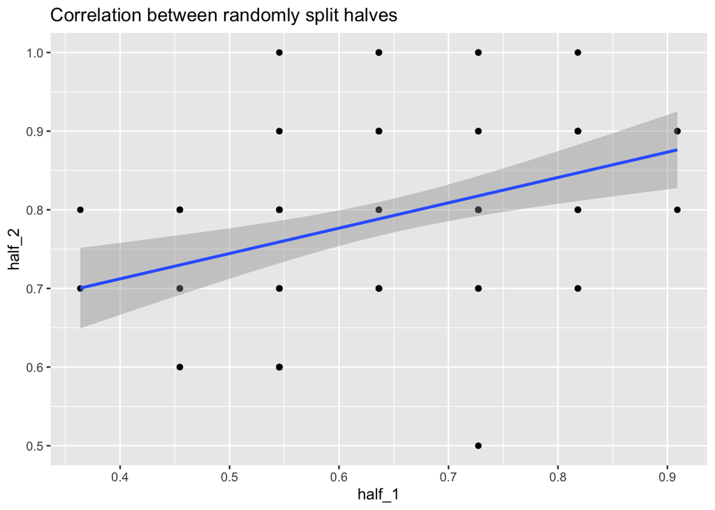

```r
ggplot(halves_scores, aes(y = half_2, x = half_1)) +
  geom_point() +
  geom_smooth(formula = "y ~ x", method = "lm") +
  labs(title = "Correlation between randomly split halves")
```

We will additionally calculate Cronbach’s $\alpha$, having removed the “Try scale” items (which will be addressed later) to ensure unidimensionality(hopefully):

```r
cron_bin <- cart_bin |>
  select(-did_best, -group, -score, -einstein, -panda, -color_red, -computer_science)
psych::alpha(cron_bin)
```

```
Some items ( NCMO farming population housing harvest_dummy ) were negatively correlated with the total scale and
probably should be reversed.
To do this, run the function again with the 'check.keys=TRUE' option
```

```
Reliability analysis
Call: psych::alpha(x = cron_bin)

  raw_alpha std.alpha G6(smc) average_r  S/N   ase mean   sd median_r
      0.39      0.28    0.42     0.024 0.39 0.085 0.66 0.12    0.015

    95% confidence boundaries
         lower alpha upper
Feldt     0.19  0.39  0.55
Duhachek  0.22  0.39  0.55

 Reliability if an item is dropped:
              raw_alpha std.alpha G6(smc) average_r  S/N alpha se var.r  med.r
hold_music         0.38      0.26    0.40    0.0231 0.35    0.085 0.018 0.0167
stargazing         0.28      0.17    0.32    0.0132 0.20    0.100 0.017 0.0091
Devo               0.37      0.25    0.39    0.0217 0.33    0.087 0.019 0.0134
semesters          0.36      0.24    0.39    0.0207 0.32    0.088 0.018 0.0095
NCMO               0.41      0.34    0.46    0.0338 0.52    0.082 0.018 0.0257
farming            0.40      0.30    0.42    0.0273 0.42    0.083 0.018 0.0212
mcmidnight         0.34      0.21    0.35    0.0175 0.27    0.091 0.017 0.0088
population         0.42      0.32    0.44    0.0305 0.47    0.080 0.018 0.0246
fhe                0.40      0.29    0.42    0.0265 0.41    0.083 0.018 0.0141
snowballs          0.41      0.29    0.41    0.0264 0.41    0.081 0.018 0.0134
housing            0.44      0.35    0.46    0.0340 0.53    0.076 0.018 0.0257
grocery            0.37      0.26    0.40    0.0230 0.35    0.087 0.018 0.0167
republican         0.40      0.32    0.44    0.0303 0.47    0.084 0.018 0.0212
parks_dummy        0.24      0.14    0.28    0.0111 0.17    0.106 0.014 0.0134
harvest_dummy      0.40      0.31    0.43    0.0289 0.45    0.083 0.017 0.0167
mc_dummy           0.21      0.11    0.24    0.0083 0.13    0.111 0.013 0.0091

 Item statistics
                n  raw.r std.r   r.cor  r.drop mean   sd
hold_music    100  0.321 0.301  0.1863  0.0903 0.39 0.49
stargazing    100  0.555 0.523  0.5564  0.3548 0.44 0.50
Devo          100  0.270 0.331  0.2238  0.1426 0.92 0.27
semesters     100  0.361 0.355  0.2667  0.1525 0.72 0.45
NCMO          100 -0.047 0.059 -0.2079 -0.1405 0.96 0.20
farming       100  0.124 0.205  0.0497 -0.0211 0.90 0.30
mcmidnight    100  0.422 0.427  0.4154  0.2165 0.70 0.46
population    100  0.097 0.134 -0.0793 -0.0838 0.83 0.38
```

[output cut: 12 more lines]

```
stargazing    0.56 0.44    0
Devo          0.08 0.92    0
semesters     0.28 0.72    0
NCMO          0.04 0.96    0
farming       0.10 0.90    0
mcmidnight    0.30 0.70    0
population    0.17 0.83    0
fhe           0.19 0.81    0
snowballs     0.58 0.42    0
housing       0.38 0.62    0
grocery       0.39 0.61    0
republican    0.04 0.96    0
parks_dummy   0.57 0.43    0
harvest_dummy 0.88 0.12    0
mc_dummy      0.56 0.44    0
```

As we will see later, there are several items who correlate so poorly that more of the BYU students than the Rexburgians answered correctly. The Alpha calculation indicates several items we might remove. If we take out the ones that it indicates, we are left with the following, drastically shorter test:

```r
cron_bin2 <- cron_bin |>
  select(-housing, -owned_by, -population, -snowballs, -harvest_dummy, -NCMO, -farming, -hold_music)
psych::alpha(cron_bin2)
```

```
Reliability analysis
Call: psych::alpha(x = cron_bin2)

  raw_alpha std.alpha G6(smc) average_r S/N   ase mean   sd median_r
      0.59      0.55    0.58      0.12 1.2 0.058 0.67 0.21      0.1

    95% confidence boundaries
         lower alpha upper
Feldt     0.46  0.59   0.7
Duhachek  0.48  0.59   0.7

 Reliability if an item is dropped:
            raw_alpha std.alpha G6(smc) average_r  S/N alpha se var.r med.r
stargazing       0.55      0.50    0.53     0.111 1.00    0.064 0.020 0.100
Devo             0.58      0.54    0.57     0.128 1.17    0.059 0.024 0.100
semesters        0.58      0.54    0.57     0.128 1.17    0.058 0.023 0.100
mcmidnight       0.56      0.51    0.54     0.114 1.03    0.061 0.023 0.095
fhe              0.60      0.55    0.58     0.135 1.25    0.056 0.023 0.135
grocery          0.58      0.52    0.55     0.120 1.09    0.058 0.024 0.100
republican       0.60      0.59    0.61     0.151 1.43    0.057 0.019 0.143
parks_dummy      0.47      0.43    0.45     0.087 0.76    0.076 0.013 0.049
mc_dummy         0.46      0.43    0.44     0.086 0.76    0.078 0.010 0.064

 Item statistics
              n raw.r std.r r.cor r.drop mean   sd
stargazing  100  0.55  0.51 0.421 0.3191 0.44 0.50
Devo        100  0.32  0.40 0.235 0.1825 0.92 0.27
semesters   100  0.42  0.40 0.233 0.1896 0.72 0.45
mcmidnight  100  0.49  0.49 0.371 0.2706 0.70 0.46
fhe         100  0.32  0.35 0.168 0.1175 0.81 0.39
grocery     100  0.46  0.45 0.314 0.2227 0.61 0.49
republican  100  0.11  0.24 0.015 0.0077 0.96 0.20
parks_dummy 100  0.71  0.67 0.699 0.5372 0.43 0.50
mc_dummy    100  0.73  0.67 0.722 0.5642 0.44 0.50

Non missing response frequency for each item
               0    1 miss
stargazing  0.56 0.44    0
Devo        0.08 0.92    0
semesters   0.28 0.72    0
mcmidnight  0.30 0.70    0
fhe         0.19 0.81    0
grocery     0.39 0.61    0
republican  0.04 0.96    0
parks_dummy 0.57 0.43    0
mc_dummy    0.56 0.44    0
```

as we can see, the $\alpha$ and $\lambda$ coefficients are much higher, despite a shorter test.

### “Didn’t try/pay attention” Scale

Using the predetermined items, we can calculate a Try Scale score for each respondent. As seen below, there are 2 individuals who scored a 2 on the Try Scale.

```r
cart_long <- cart_bin |>
  mutate(id = 1:nrow(cart_bin)) |>
  pivot_longer(cols = 2:23, names_to = "item", values_to = "response")

try_scale <- cart_long |>
  group_by(id) |>
  filter(item %in% c("einstein", "panda", "color_red", "computer_science")) |>
  summarize(tried = sum(response))
pander(table(try_scale$tried))
```

| 2 | 3 | 4 |
| --- | --- | --- |
| 2 | 23 | 75 |

```r
cart_long <- cart_long |>
  filter(id != c(28,40))

t_sd <- sd(try_scale$tried)
t_mu <- 4
t_xb <- 2
t_n <- length(try_scale$tried)

t_score <- (t_xb - t_mu) / (t_sd / sqrt(t_n))
```

It is very unlikely that an individual would score a 2 if they were in fact trying their best. Assuming that an individual trying their best would get a 4, we can do a t-test, which results in a t-score of approximately -40 and thus a p-value very near 0. Therefore, we will remove those individuals whose Try_Scale score is a 2.

## Validity

We will attempt to demonstrate group differentiation. First, we format the data to distinguish between those in our “Rexburg Resident” group and those in Utah vs. elsewhere. Then, we will calculate scores for each student and perform an ANOVA to determine whether mean scores differ across groups.

```r
group_val <- cart_long |>
  group_by(id) |>
  summarize(score = sum(response),
            group = as.factor(group)) |>
  distinct()

group_nov <- aov(score ~ group, data = group_val)

pander(summary(group_nov))
```

Analysis of Variance Model

|  | Df | Sum Sq | Mean Sq | F value | Pr(>F) |
| --- | --- | --- | --- | --- | --- |
| **group** | 2 | 236.9 | 118.4 | 29.77 | 8.284e-11 |
| **Residuals** | 97 | 385.9 | 3.978 | NA | NA |

```r
tukeyout <- TukeyHSD(group_nov, "group")

#pairwise.t.test(group_val$score, group_val$group, adjust = "bonferroni")
```

As we can see, there is a significant effect in group. To identify which groups are different from each other, we will consult a Tukey’s Honest Significant Difference adjusted pairwise t-test. The results are summarized in a plot below, where a line intersecting the dotted line at 0 is nonsignificant and a line that doesn’t touch 0 is significant. It is most important that the 0-1 group is significant, so that’s the line we are looking at:

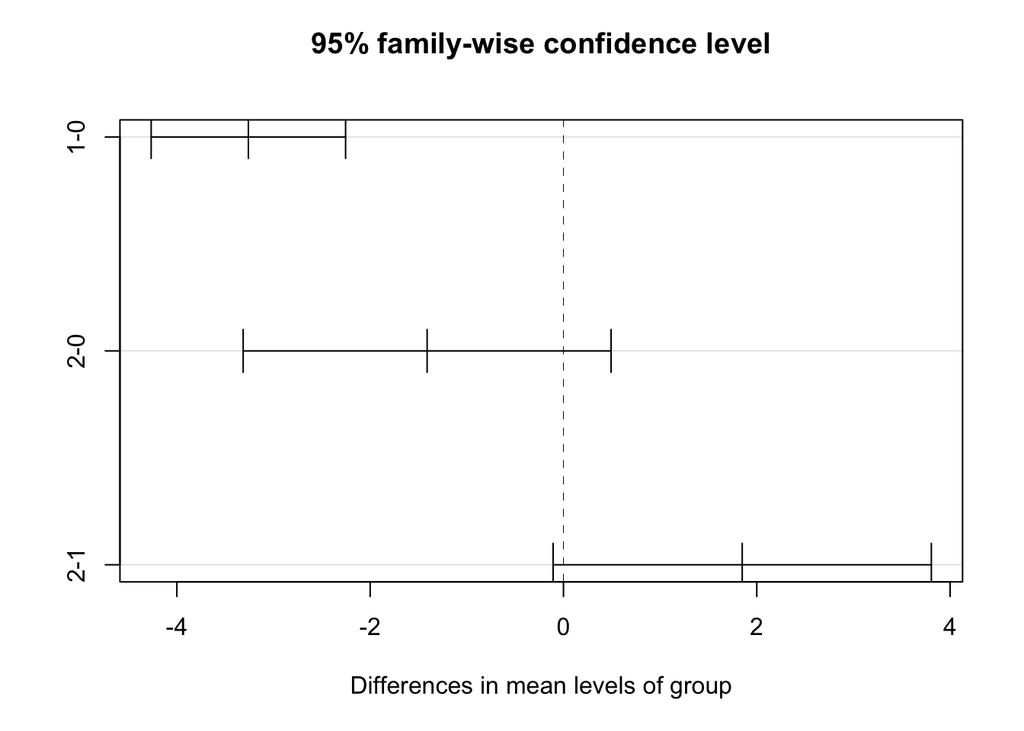

```r
plot(tukeyout)
```

As we can see, there is a significant difference in mean scores between the Rexburg Resident group and the Utah resident group. This indicates that our test is successful in identifying those who are/are not Rexburgians.

Additionally, we can visualize a density plot/histogram of the CART scores according to the respondent group.

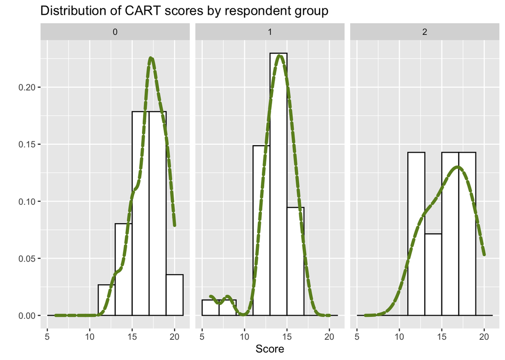

```r
ggplot(group_val, aes(x = score)) +
  geom_histogram(aes(y = ..density..), fill = "white", color = "black", binwidth = 2) +
  #geom_dotplot(aes(y = ..density..)) +
  geom_density(color = "olivedrab", linetype = "3121", size = 1.5 ) +
  #stat_function(fun = function(x) mean(x), geom = "line", color = "firebrick") +
  facet_wrap(facets = vars(group)) +
  labs(title = "Distribution of CART scores by respondent group",
       y = "",
       x = "Score")
```

### Item difficulty analysis

Having reformatted each item, we can find combined difficulties across the test as well as difficulty between groups. Doing so will help us determine which, if any, questions should be re-worked or removed entirely.

```r
item_difficulty <- cart_long |>
  filter(! item %in% c("group", "did_best")) |>
  group_by(item) |>
  summarize(difficulty = sum(response) / n()) |>
  arrange(difficulty)

difficulty_by_group <- cart_long |>
  filter( item != "did_best") |>
  group_by(item, group) |>
  summarize(difficulty = sum(response) / n()) |>
  pivot_wider(names_from = group, values_from = difficulty, names_prefix = "group_") |>
  arrange(group_0)

difficulty_all <- inner_join(item_difficulty, difficulty_by_group, by = "item") |>
  mutate(GoodQ = if_else(group_0 > difficulty , if_else(difficulty > group_1 & difficulty > group_2, "Yes", "Maybe"), "Delete")) |>
  arrange(GoodQ)
names(difficulty_all) <- c("item", "difficulty", "Rexburg", "Utah", "Other", "Good Question")


pander::pander(difficulty_all)
```

| item | difficulty | Rexburg | Utah | Other | Good Question |
| --- | --- | --- | --- | --- | --- |
| harvest_dummy | 0.1212 | 0.1071 | 0.1667 | 0 | Delete |
| snowballs | 0.4242 | 0.4107 | 0.4722 | 0.2857 | Delete |
| housing | 0.6162 | 0.5357 | 0.6944 | 0.8571 | Delete |
| computer_science | 0.8586 | 0.8393 | 0.8889 | 0.8571 | Delete |
| farming | 0.9091 | 0.8929 | 0.9444 | 0.8571 | Delete |
| NCMO | 0.9596 | 0.9464 | 0.9722 | 1 | Delete |
| color_red | 1 | 1 | 1 | 1 | Delete |
| einstein | 1 | 1 | 1 | 1 | Delete |
| owned_by | 1 | 1 | 1 | 1 | Delete |
| mcmidnight | 0.697 | 0.8393 | 0.4722 | 0.7143 | Maybe |
| fhe | 0.8182 | 0.8571 | 0.75 | 0.8571 | Maybe |
| population | 0.8384 | 0.8393 | 0.8056 | 1 | Maybe |
| panda | 0.899 | 0.9107 | 0.8611 | 1 | Maybe |
| Devo | 0.9192 | 0.9464 | 0.8611 | 1 | Maybe |
| republican | 0.9596 | 0.9643 | 0.9444 | 1 | Maybe |
| hold_music | 0.3838 | 0.4464 | 0.3056 | 0.2857 | Yes |
| parks_dummy | 0.4242 | 0.6786 | 0.05556 | 0.2857 | Yes |
| stargazing | 0.4343 | 0.625 | 0.1389 | 0.4286 | Yes |
| mc_dummy | 0.4444 | 0.75 | 0 | 0.2857 | Yes |
| grocery | 0.6061 | 0.7143 | 0.4722 | 0.4286 | Yes |
| semesters | 0.7172 | 0.8214 | 0.5556 | 0.7143 | Yes |

As we can see, there are 6 items which are indicated as being “high-quality” (whatever that means in this context), 6 with questionable discrimination/usefulness, and 9 items where the Rexburg group either did worse or no better than the Utah/Other groups.